# Hardware prototyping workflow

Tavish Naruka

# Prototyping

These are some things I learnt about the way to approach a hardware/mixed domain project in the last ~2 years

This is supposed to give an overview of the things that are done/considered in a project

## Overview of how things are usually done

- Component selection
  - The main 'cores' for which provide the most functionality are the first things to think about
  - Can be a microcontoller, microprocessor, FPGA, ASIC etc., or can be something simpler for not too complicated neeeds
  - based on constraints like price, availability with vendors, supporting components, size, power requirement, heat, input voltage etc.
  - familiarity, ease of use, support, toolchains or other supporting software
  - availability of documentation/schematics from manufacturer or other people
- Sometimes can choose to use a development board, sometimes they are not what is needed, or expensive or not available
- Prototype on breadboard or prfboard or stripboard (not always possible)
  - Not all components are available as DIP, sometimes there are too many lines
  - Breadboards/connecting wires dont have good electromagnetic characteristics, sometimes cannot use with high speed parts

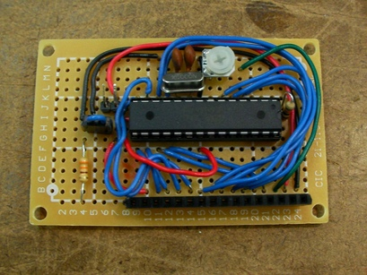

  - perfboard

- PCB prototype
  - Printed cicuit board is conducting metal laminated over a non-conducting substrate
  - First step for making this is a correct schematic

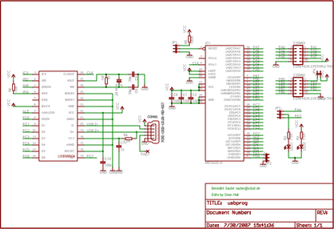

  - A schematic

After schematic comes layout

- PCBs can be single layer, dual, multiple layers.
- Single can sometimes be made at home
- PCBs serve a few puposes, like providing conducting paths, heat sink, mechanical support

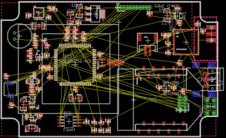

- unrouted but placed components

Now routed

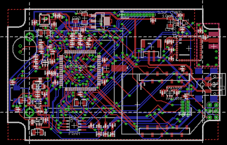

- routed pcb

- Green gots here connect the two layers on this pcb, they are called vias
- Placement is important, like crystals close to uC, decoupling capacitors too
- Mounting holes, connector placement, casing choice
- Path lengths and presense of other tracks nearby change resistance of tracks, also capacitance and inductance
- differential signals and high speed parallel signals like USB or connections from RAM need length and impedance matching
- RF design

A shielded PCB with an antenna on it

[figure not shown]

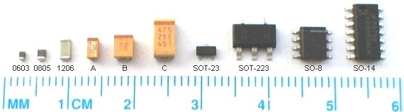

- smd sizes

# Using a microcontroller in design

Firmware

- If using a microcontroller, most code is in C, and assembly. Sometimes C++.
- Some peripherals and stacks can be complex, so compilers and chip makers often provides driver libraries and example code for things like USB, ethernet, and other peripherals and sometimes for some external components too
- The reference manual is usually a reference for a family of similar chips, and the datasheet is the ultimate reference

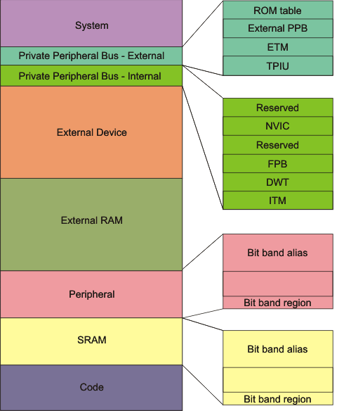

ARM cortex m3 memory map

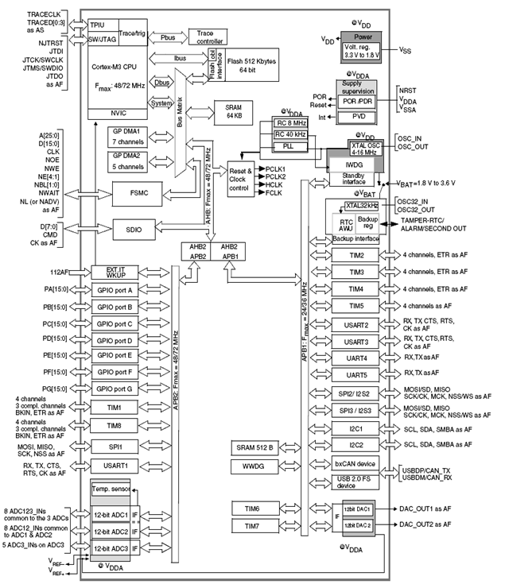

Peripherals and clocks

- Things you need to read in the manuals
  - memory layout
  - how does the chip boot code
  - how do interrupts work in this particular chip
  - system clocks
  - about any peripherals you want to use

The code that is generated for executing for a desktop is called hosted; the host operating system prrovides the code a 'runtime environment'

The code that is run on a microcontroller is called freestanding. The compiler, or you have to provide the C runtime.

C runtime here means the startup code, which loads and initialzes different sections of the code. Like global variables, which are not initialized are set to 0, initialized variables in code need to be initialized, jumping to main(), etc.

The entry point of your code is usually called 'Reset vector', and that would be the start of your startup code, which would jump to your code afterwards, usually a function named main().

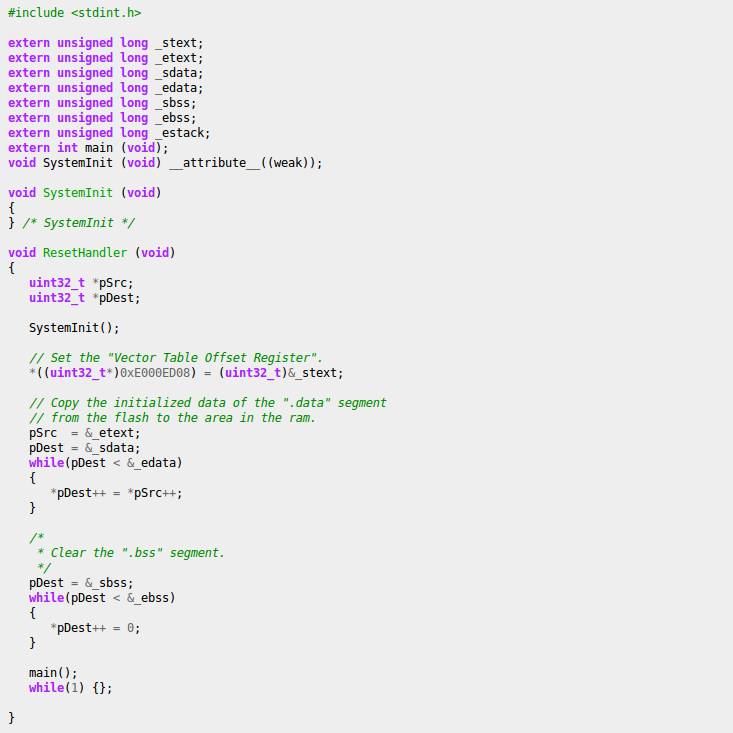

crt

Usually this code should not work since this C code seems to be using stack (the two variables pDst, pSrc). It works because of the stack pointer is setup at boot, and there are stack push and stack pop instructions.

More control over the memory layout is needed when dealing with microcontrollers.

For this, we need to use linker scripts, which are used by the linker portion of toolchain to arrange code. (initialized memory, unitialized memory, stack, function code, or even blocks of assembly, interrupt vectors).

This kind of control is also needed for bootloades for microcontrollers. For example, the code being flashed by the bootloder should not have anything to do with the portion of flash where the bootloader resides. So the person making an application uses a linker script where the portion of flash used by bootloader is not mapped.

Or the platform chosen can run Linux. But

- It is much easier to do some kinds of things on a microcontroller. Especially things which are time critial or which require realtime behavior.
- Real time behavior is when the system needs to do something within a time limit. Sometimes things dont work if there is a latency or jitter between an event happening and the system doing something
- Things like USB devices are meant to be realized with dedicated systems not general purpose computers.
- Easier tweaking of low level things, could be cheaper, could be easier if system is simple

On the other hand

- It is much much easier to develop your application on a system running linux.
- Lots of things have already been done, so you dont have to reinvent the wheel.
- debugging is easier
- A choice of many languages, C, lua, python, shell, even javascript etc.
- Filesystems, networking, graphics etc. These things may also be done on a some microcontroller, but with a lot more effort.